# AFDMD-111 Estadística

Cálculo de probabilidad de VAs

# Variables aleatorias discretas

Como se ha mencionado en clases pasadas existen tres tipos de variables aleatorias; discretas, continuas y mixtas. Para nuestro curso, estaremos interesados en las variables aleatorias discretas y continuas. Recordemos que para las variables aleatorias discretas contamos con dos funciones que las describen totalmente; la función de distribución y la función de densidad. La función de distribución está dada por:
$$F_X(x) = P(X \le x)$$
para cualquier valor $x \in \mathbb{R}$. La función de masa de probabilidad es la otra función que se define de la siguiente manera:
$$p_X(k) = P(X=k)$$
Por lo tanto, cuando se nos dá una variable aleatoria discreta ésta está definida por una fórmula que representa $p_X(k)$ o $F_X(x)$. La variable aleatoria binomial, por ejemplo está dada por:
$$p_X(k) = \binom{n}{k}p^k(1-p)^{n-k}\; \;\;\; k=0,1,2, \ldots n$$
En R, los comandos `dbinom, pbinom, rbinom` y `qbinom` generan las pmfs, distribuciones y números aleatorios relacionados a la variable aleatoria discreta Binomial. Por ejemplo, el siguiente código genera $100$ números aleatorios de una distriubción binomial con parámetros $n=16$, $p=0.1$ y posteriormente se grafican.

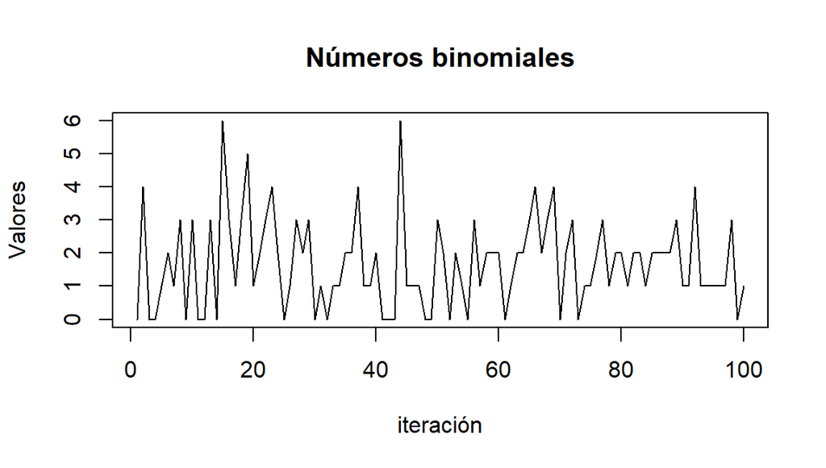

```r
vars <-rbinom(100, size=16, prob=0.1)
plot(vars, type="l", main="Números binomiales", xlab="iteración", ylab="Valores")
```

## Actividad

Investigue la generación de *pmfs* y *cdfs* discretas en R o python y posteriormente calcule las siguientes probabilidades usando únicamente código:

1. Sea $X$ una variable aleatoria que tiene distribución binomial con $p=0.4$ y $n=20$. Calcular:
1. $P(X\le 6)$

```r
p <- 0.4
n <- 20

prob_x_leq_6 <- pbinom(6, n, p)
print(prob_x_leq_6)
```

```
## [1] 0.2500107
```

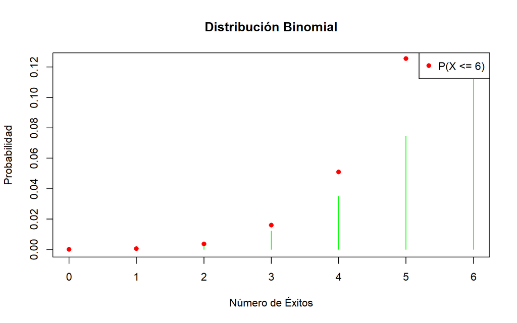

```r
p <- 0.4
n <- 20

prob_x_leq_6 <- pbinom(0:6, n, p)

iteraciones <- 0:6

vars <- dbinom(iteraciones, n, p)

plot(iteraciones, vars, type="h", main="Distribución Binomial", xlab="Número de Éxitos", ylab="Probabilidad", col="green")
points(iteraciones, prob_x_leq_6, col="red", pch=16)
legend("topright", legend=c("P(X <= 6)"), col="red", pch=16)
```

2. $P(X\ge 12)$

```r
p <- 0.4
n <- 20

prob_x_lt_12 <- pbinom(11, n, p)

prob_x_geq_12 <- 1 - prob_x_lt_12
print(prob_x_geq_12)
```

```
## [1] 0.05652637
```

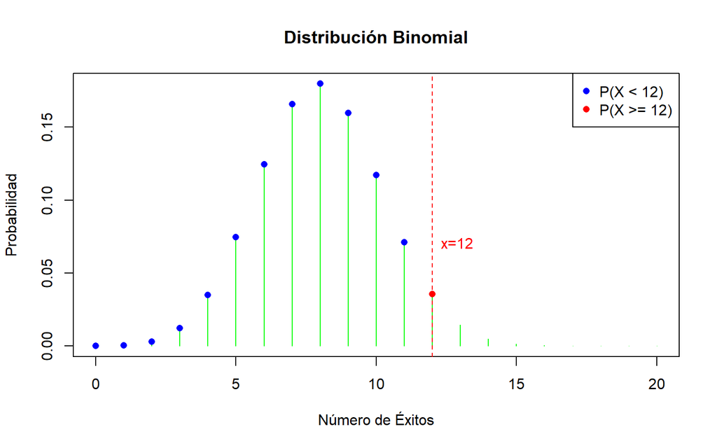

```r
p <- 0.4
n <- 20

prob_x_lt_12 <- pbinom(11, n, p)

prob_x_geq_12 <- 1 - prob_x_lt_12

iteraciones <- 0:20

vars <- dbinom(iteraciones, n, p)

plot(iteraciones, vars, type="h", main="Distribución Binomial", xlab="Número de Éxitos", ylab="Probabilidad", col="green")
abline(v=12, col="red", lty=2)  # Línea vertical en x = 12
text(12, 0.07, "x=12", pos=4, col="red")  # Etiqueta en x = 12
points(0:11, dbinom(0:11, n, p), col="blue", pch=16)  # Puntos para P(X < 12)
points(12, dbinom(12, n, p), col="red", pch=16)  # Punto para P(X >= 12)

legend("topright", legend=c("P(X < 12)", "P(X >= 12)"), col=c("blue", "red"), pch=16)
```

3. $P(X=8)$

```r
p <- 0.4
n <- 20

prob_x_eq_8 <- dbinom(8, n, p)
print(prob_x_eq_8)
```

```
## [1] 0.1797058
```

```r
p <- 0.4
n <- 20

prob_x_eq_8 <- dbinom(8, n, p)
print(prob_x_eq_8)
```

```
## [1] 0.1797058
```

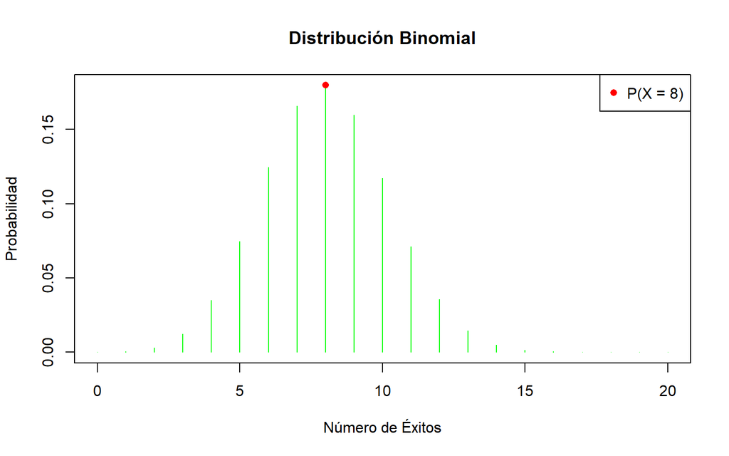

```r
iteraciones <- 0:n

vars <- dbinom(iteraciones, n, p)

plot(iteraciones, vars, type="h", main="Distribución Binomial", xlab="Número de Éxitos", ylab="Probabilidad", col="green")
points(8, prob_x_eq_8, col="red", pch=16)  # Punto para P(X = 8)

legend("topright", legend=c("P(X = 8)"), col="red", pch=16)
```

2. El comando `sample`, me permite generar números aleatorios con una *pmf* que define el usuario. Generar 100 números aleatorios con las siguientes pmfs:
1. $p_X(k) = {5\choose k}\left(\frac{1}{5}\right)^k \left(\frac{4}{5}\right)^{5-k}, \;\; k=0,1,2,3,4,5.$

```r
pX <- function(k) {ifelse(k >= 0 & k <= 5, choose(5, k) * (1/5)^k * (4/5)^(5-k), 0)}

set.seed(123)
n <- 100

random_numbers <- sample(0:5, n, replace = TRUE, prob = sapply(0:5, pX))

print(random_numbers)
```

```
##   [1] 1 2 1 2 2 1 0 2 0 0 3 0 0 0 1 2 1 1 1 3 2 0 0 4 0 0 0 0 1 1 3 2 0 2 1 0 2
##  [38] 1 1 1 1 0 0 1 1 1 1 0 1 2 1 0 2 1 0 1 1 2 2 1 0 1 1 1 2 0 2 2 2 0 2 0 0 1
##  [75] 0 1 1 0 1 1 1 0 0 2 1 0 3 2 2 1 1 0 1 0 1 1 2 1 0 0
```

2. $p_X(k) = \frac{k^2}{2870}, \;\; k=0,1,2,3,\ldots, 19, 20$

```r
pX <- function(k) {ifelse(k >= 0 & k <= 20, (k^2) / 2870, 0)}

set.seed(123)
n <- 100

random_numbers <- sample(0:20, n, replace = TRUE, prob = sapply(0:20, pX))

print(random_numbers)
```

```
##   [1] 18 12 17 10  8 20 16 10 16 17  7 17 14 15 20 10 19 20 18  7 10 14 15  4 14
##  [26] 14 16 15 18 19  7  9 14 12 20 17 13 19 18 19 19 17 17 18 19 20 19 17 18 11
##  [51] 20 17 12 20 16 19 20 13 10 18 14 20 17 18 12 17 12 12 12 17 13 15 14 20 17
##  [76] 19 17 15 18 20 19 14 17 12 20 17  5 10 10 19 20 14 18 14 18 19 12 20 17 16
```

3. $p_X(k) = \log_{10}\left(\frac{k+1}{k}\right)\; \; k=1,2,3, \ldots 9$

```r
pX <- function(k) {ifelse(k >= 1 & k <= 9, log10((k + 1) / k), 0)}

set.seed(123)
n <- 100

random_numbers <- sample(1:9, n, replace = TRUE, prob = sapply(1:9, pX))

print(random_numbers)
```

```
##   [1] 1 6 2 7 8 1 3 7 3 2 9 2 4 3 1 7 1 1 2 9 7 4 4 9 4 5 3 3 1 1 9 7 4 6 1 3 5
##  [38] 1 2 1 1 2 2 2 1 1 1 2 1 7 1 2 6 1 3 1 1 5 7 2 4 1 2 1 6 2 6 6 6 2 5 4 5 1
##  [75] 2 1 2 4 2 1 1 4 2 6 1 2 9 7 7 1 1 4 2 4 2 1 6 1 2 3
```

3. La variable aleatoria binomial depende de los parámetros $n$ y $p$. Grafique las pmfs y cdfs para (Nota para graficar por parejas puede usar el comando `par(mfrow=(filas, columnas))`) y responda las preguntas:
1. $n=10$ y $p=1/2$

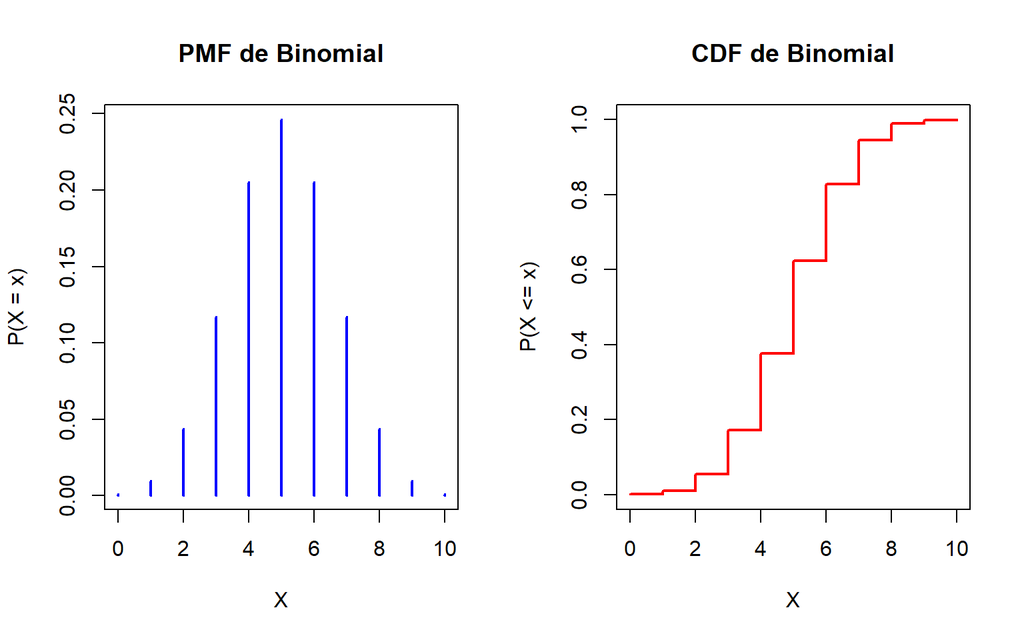

```r
n <- 10
p <- 1/2

x <- 0:n

pmf <- dbinom(x, size = n, prob = p)

cdf <- pbinom(x, size = n, prob = p)

par(mfrow = c(1, 2))

plot(x, pmf, type = "h", lwd = 2, col = "blue", main = "PMF de Binomial", xlab = "X", ylab = "P(X = x)")

plot(x, cdf, type = "s", lwd = 2, col = "red",  main = "CDF de Binomial", xlab = "X", ylab = "P(X <= x)")
```

```r
par(mfrow = c(1, 1))
```

2. $n=10$ y $p=1/8$

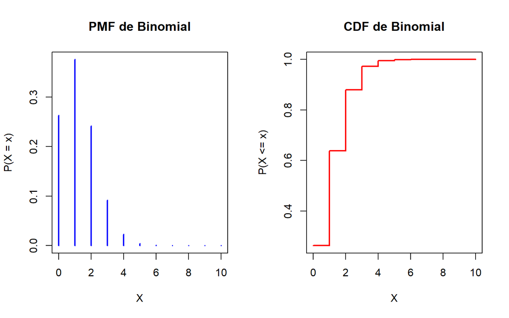

```r
n <- 10
p <- 1/8

x <- 0:n

pmf <- dbinom(x, size = n, prob = p)

cdf <- pbinom(x, size = n, prob = p)

par(mfrow = c(1, 2))

plot(x, pmf, type = "h", lwd = 2, col = "blue", main = "PMF de Binomial", xlab = "X", ylab = "P(X = x)")

plot(x, cdf, type = "s", lwd = 2, col = "red", main = "CDF de Binomial", xlab = "X", ylab = "P(X <= x)")
```

```r
par(mfrow = c(1, 1))
```

3. $n=10$ y $4/5$

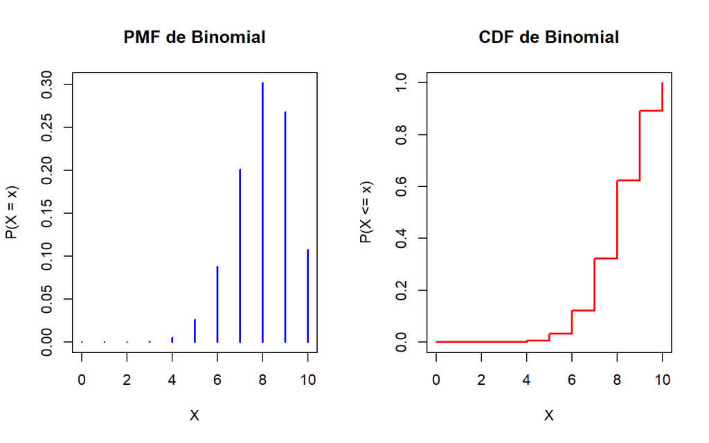

```r
n <- 10
p <- 4/5

x <- 0:n

pmf <- dbinom(x, size = n, prob = p)

cdf <- pbinom(x, size = n, prob = p)

par(mfrow = c(1, 2))

plot(x, pmf, type = "h", lwd = 2, col = "blue",main = "PMF de Binomial", xlab = "X", ylab = "P(X = x)")

plot(x, cdf, type = "s", lwd = 2, col = "red",main = "CDF de Binomial", xlab = "X", ylab = "P(X <= x)")
```

```r
par(mfrow = c(1, 1))
```

4. $n=10$ y $p=1/2$

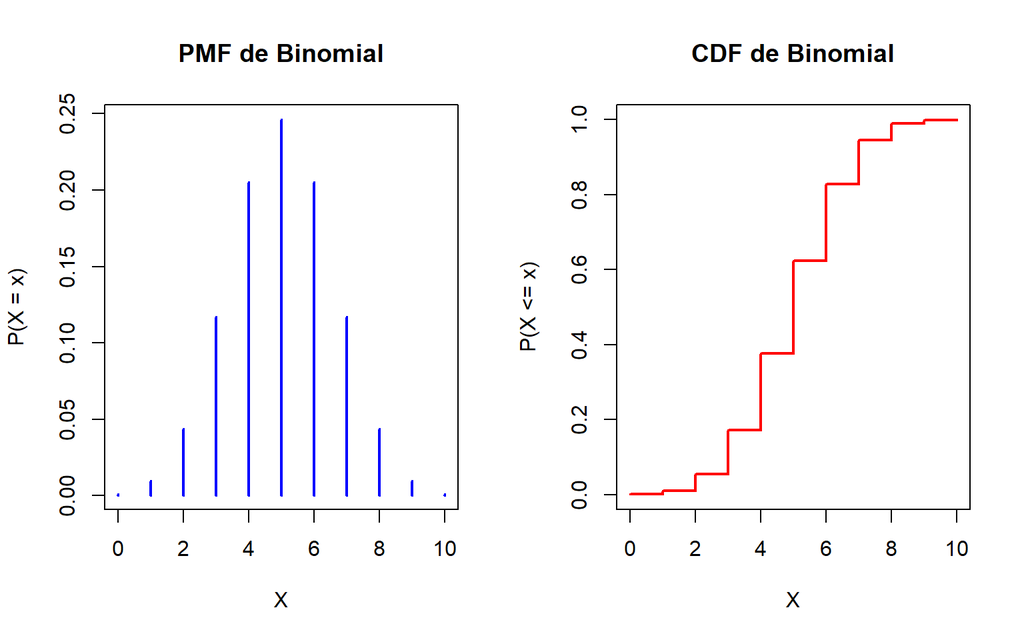

```r
n <- 10
p <- 1/2

x <- 0:n

pmf <- dbinom(x, size = n, prob = p)

cdf <- pbinom(x, size = n, prob = p)

par(mfrow = c(1, 2))

plot(x, pmf, type = "h", lwd = 2, col = "blue", main = "PMF de Binomial", xlab = "X", ylab = "P(X = x)")

plot(x, cdf, type = "s", lwd = 2, col = "red", main = "CDF de Binomial", xlab = "X", ylab = "P(X <= x)")
```

```r
par(mfrow = c(1, 1))
```

3. ¿Tiene algún efecto $n$ y $p$ para que la pmf sea simétrica? ¿Cuál?
- cuando P=1/2 en una distribucion binominal, la probalilidad de exito en cada ensayo es igual a la probabilidad de fracaso, por lo tanto si tienes un numero par de ensayos, entonces la probalilidad de obtener k exitos sera igual a la probabilidad de obtener n-k exitos. esto da lugar a una distribucion simetrica alrededor de k=n/2.
4. ¿Qué efecto tiene $p$ en la asimetría?
- cuando p se acerca a 0 u 1, la distribucion binominal se vuelve mas asimetrica. Especificamente si p se acerca a 0, la distribucion sera asimetrica hacia la derecha, y si p se acerca a 1 la distribucion sera asimetrica hacia la izquierda

# Variables aletorias continuas

Las variables aleatorias continuas, a diferencia de las discretas, quedan totalmente definidas mediante su PDF y CDF. Existen múltiples variables aleatorias bien conocidas y que sirven para modelar diversos fenómenos. La densidad Gamma está dada por la siguiente ecuación:
$$f_X(x, \alpha, \beta) = \begin{cases}
\frac{\beta^{\alpha}}{\Gamma(\alpha)} x^{\alpha-1} \mbox{e}^{-\beta x}
& x>0\\
0 & x\le 0
\end{cases}$$
donde $\alpha>0$ y $\beta >0$.

## Actividad

1. ¿Qué efecto tiene incrementar $\alpha$? Grafique para contestar.

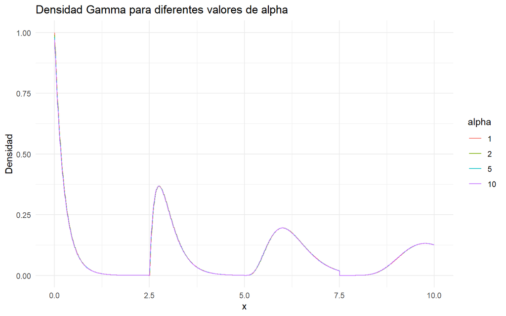

```r
library(ggplot2)
library(gamma)

x <- seq(0, 10, length = 1000)

alphas <- c(1, 2, 5, 10)

df <- data.frame(x = rep(x, each = length(alphas)), alpha = rep(alphas, times = length(x)), density = dgamma(x, shape = rep(alphas, each = length(x))))

ggplot(df, aes(x = x, y = density, color = as.factor(alpha))) + geom_line() + labs(title = "Densidad Gamma para diferentes valores de alpha",x = "x",y = "Densidad") + scale_color_discrete(name = "alpha") +theme_minimal()
```

2. ¿Qué efecto tiene $\beta$ en la forma de la densidad? Grafique para contestar.

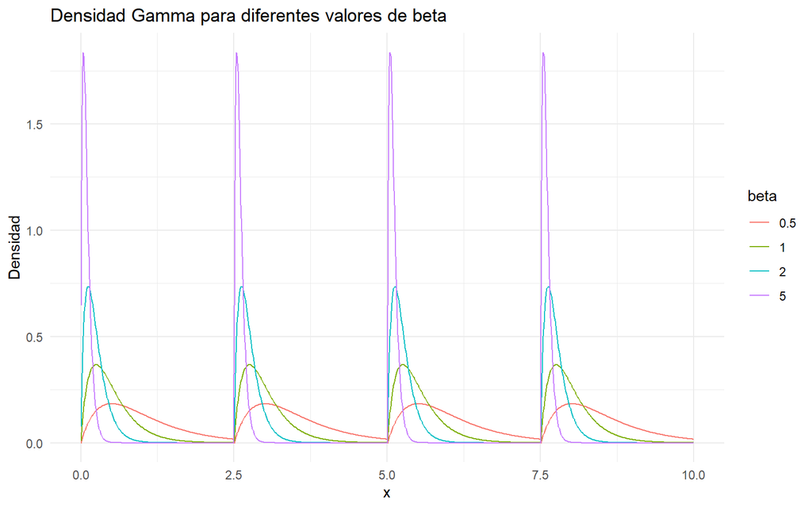

```r
betas <- c(0.5, 1, 2, 5)

df_beta <- data.frame(x = rep(x, each = length(betas)), beta = rep(betas, times = length(x)), density = dgamma(x, shape = 2, rate = betas))

ggplot(df_beta, aes(x = x, y = density, color = as.factor(beta))) + geom_line() + labs(title = "Densidad Gamma para diferentes valores de beta", x = "x", y = "Densidad") + scale_color_discrete(name = "beta") + theme_minimal()
```

## Actividad

1. ¿Qué efecto tiene $\beta$ en la función de densidad? Grafique para contestar.

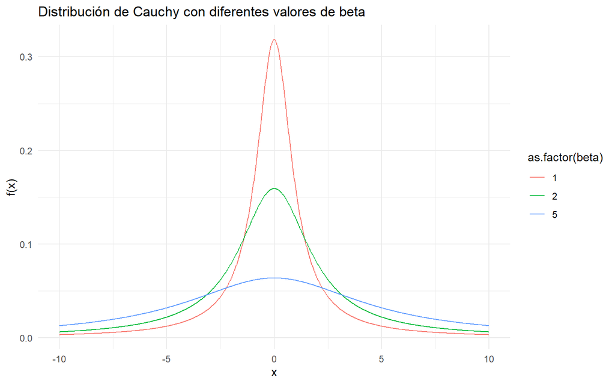

```r
library(ggplot2)
cauchy_pdf <- function(x, alpha, beta) {return(beta / (pi * ((x - alpha)^2 + beta^2)))}
x_values <- seq(-10, 10, length.out = 1000)

beta_values <- c(1, 2, 5)

df <- expand.grid(x = x_values, beta = beta_values)

df$y <- cauchy_pdf(df$x, alpha = 0, beta = df$beta)

ggplot(df, aes(x, y, color = as.factor(beta))) + geom_line() + labs(title = "Distribución de Cauchy con diferentes valores de beta", x = "x", y = "f(x)") + theme_minimal()
```

Supóngamos que tenemos la siguiente PDF:
$$f_X(x) = \begin{cases}
0 & x < a\\
\frac{2(x-a)}{(b-a)(c-a)} & a \le x < c\\
\frac{2}{b-a} & x=c\\
\frac{2(b-x)}{(b-a)(b-c)} & c < x \le b\\
0 & b < x
\end{cases}$$
donde $a < c < c$.

## Actividad

1. Grafique la densidad triangular cuando $a=0$, $b=4$, $c=2$

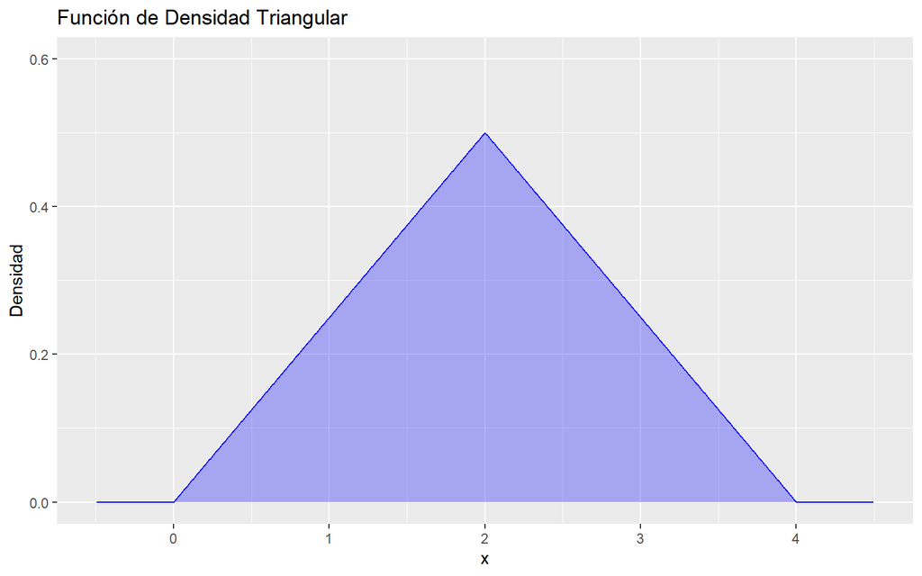

```r
library(ggplot2)

a <- 0
b <- 4
c <- 2

x <- seq(a - 1, b + 1, length.out = 1000)

density <- ifelse(x < a | x > b, 0,
                  ifelse(x < c, 2 * (x - a) / ((b - a) * (c - a)),
                         ifelse(x == c, 2 / (b - a),
                                2 * (b - x) / ((b - a) * (b - c)))))

df <- data.frame(x = x, density = density)

ggplot(df, aes(x, density)) +
  geom_line(color = "blue") +
  geom_area(fill = "blue", alpha = 0.3) +
  xlim(a - 0.5, b + 0.5) +
  ylim(0, max(density) + 0.1) +
  labs(title = "Función de Densidad Triangular", x = "x", y = "Densidad")
```

2. Grafique la densidad triangular cuando $a=1$, $c=2$, $b=4$

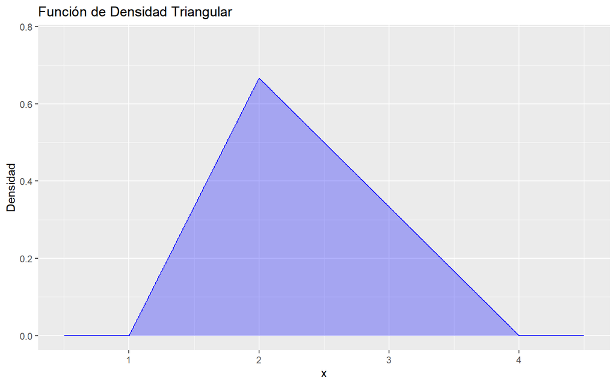

```r
library(ggplot2)
a <- 1
b <- 4
c <- 2

x <- seq(a - 1, b + 1, length.out = 1000)

density <- ifelse(x < a | x > b, 0,
                  ifelse(x < c, 2 * (x - a) / ((b - a) * (c - a)),
                         ifelse(x == c, 2 / (b - a),
                                2 * (b - x) / ((b - a) * (b - c)))))

df <- data.frame(x = x, density = density)

ggplot(df, aes(x, density)) +
  geom_line(color = "blue") +
  geom_area(fill = "blue", alpha = 0.3) +
  xlim(a - 0.5, b + 0.5) +
  ylim(0, max(density) + 0.1) +
  labs(title = "Función de Densidad Triangular",
       x = "x",
       y = "Densidad")
```

3. Grafique la densidad triangular cuando $a=-1$, $c=0$, $b=1$

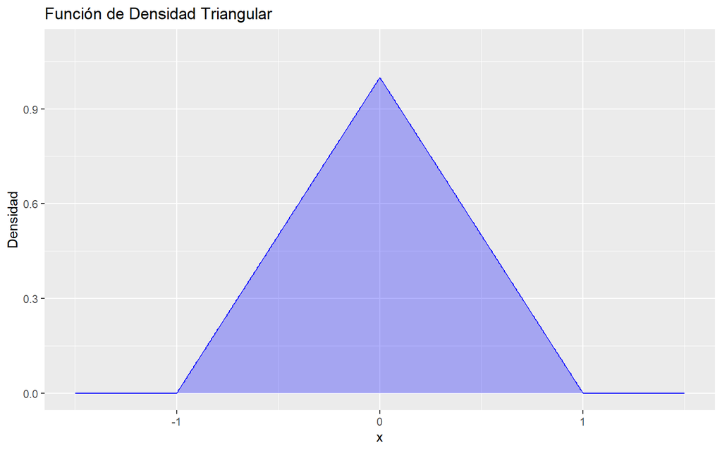

```r
library(ggplot2)

a <- -1
b <- 1
c <- 0

x <- seq(a - 1, b + 1, length.out = 1000)

density <- ifelse(x < a | x > b, 0,
                  ifelse(x < c, 2 * (x - a) / ((b - a) * (c - a)),
                         ifelse(x == c, 2 / (b - a),
                                2 * (b - x) / ((b - a) * (b - c)))))

df <- data.frame(x = x, density = density)

ggplot(df, aes(x, density)) +
  geom_line(color = "blue") +
  geom_area(fill = "blue", alpha = 0.3) +
  xlim(a - 0.5, b + 0.5) +
  ylim(0, max(density) + 0.1) +
  labs(title = "Función de Densidad Triangular",
       x = "x",
       y = "Densidad")
```

Tanto `R` como `python` nos permiten calcular integrales usando los comandos básicos o bién usando sistemas de cómputo algebraíco. R, por ejemplo, puede utilizar un sistema llamado `Ryacas` que permite hacer muchos cálculos de forma simbólica. Ahora, consideremos que tenemos la siguiente PDF:

$$f_X(x) = \begin{cases}
\mbox{e}^{-x} & x \ge 0\\
0 & \mbox{resto}
\end{cases}$$

## Actividad

Calcular, usando los comando de integración o `Ryacas` o `python` las siguientes probabilidades usando la PDF de arriba:

1. $P(X>1)$

```r
probability <- integrate(function(x) exp(-x), lower = 1, upper = Inf)$value

print(probability)
```

```
## [1] 0.3678794
```

2. $P(2 < X \le 4)$

```r
probability <- integrate(function(x) ifelse(x >= 2 & x <= 4, exp(-x), 0), lower = -Inf, upper = Inf)$value

print(probability)
```

```
## [1] 0.1170196
```

3. $P(X \le 2)$

```r
probability_x_leq_2 <- 1 - exp(-2)
print(probability_x_leq_2)
```

```
## [1] 0.8646647
```

Finalmente, supongamos que tenemos la siguiente PDF:

$$f_X(x) = \frac{1}{\sqrt{2\pi}}\mbox{e}^{-\frac{(x-3)^2}{2}}$$

## Actividad

1. Graficar $f_X(3+x)$.

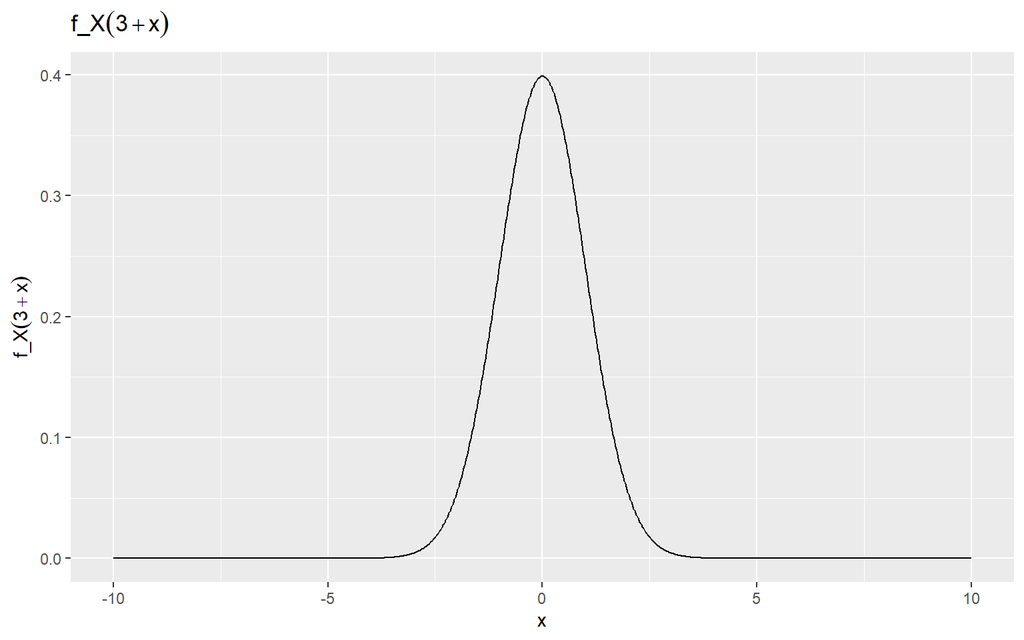

```r
library(ggplot2)
library(dplyr)
f_X_3x <- function(x) { return((1/sqrt(2*pi)) * exp(-x^2/2))}

x_values <- seq(-10, 10, length.out = 1000)

f_X_3x_values <- f_X_3x(x_values)

df <- data.frame(x = x_values, f_X_3x = f_X_3x_values)

ggplot(df, aes(x = x, y = f_X_3x)) + geom_line() + labs(title = expression(f_X(3 + x)), x = "x", y = expression(f_X(3 + x)))
```

2. Graficar $f_X(3-x)$.

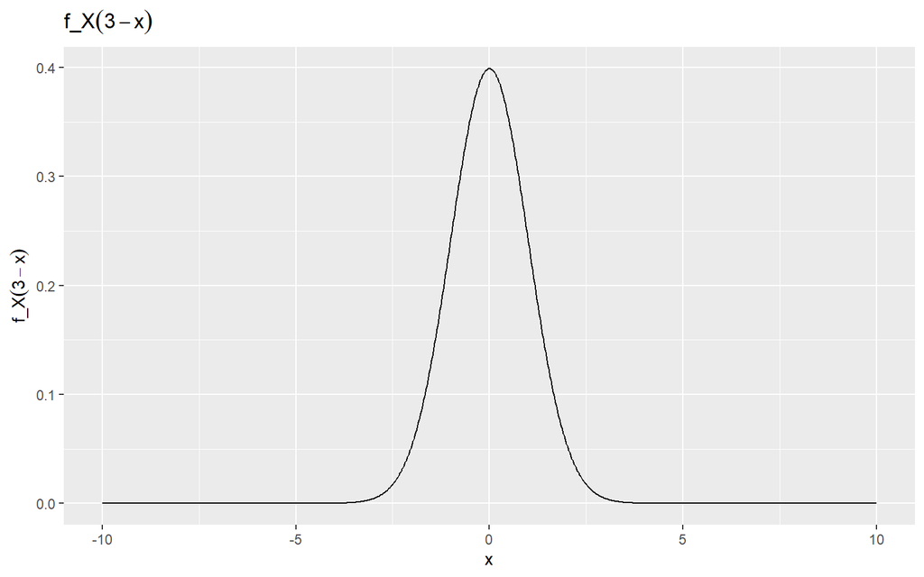

```r
library(ggplot2)
library(dplyr)

f_X_3_minus_x <- function(x) { return((1/sqrt(2*pi)) * exp(-(-x)^2/2))}
x_values <- seq(-10, 10, length.out = 1000)

f_X_3_minus_x_values <- f_X_3_minus_x(x_values)

df <- data.frame(x = x_values, f_X_3_minus_x = f_X_3_minus_x_values)

ggplot(df, aes(x = x, y = f_X_3_minus_x)) + geom_line() + labs(title = expression(f_X(3 - x)), x = "x", y = expression(f_X(3 - x)))
```

3. Que hay en común entre estas dos gráficas y qué se puede inferir de $f_X(3+x)$ y $f_X(3-x)$

## Fecha de entrega: miércoles 18 de octubre de 2023 a través de Moodle.